# Who waits longest?

England’s NHS waiting list, analysed in R

```r
# everything here reads the cleaned tables in data/clean, built from data/raw by scripts/01_clean.R
source("R/rtt.R")
library(ggplot2)
library(scales)
library(jsonlite)
ts   <- read_csv("data/clean/england_timeseries.csv", show_col_types = FALSE)
spec <- read_csv("data/clean/specialty_summary.csv", show_col_types = FALSE)
prov <- read_csv("data/clean/provider_summary.csv", show_col_types = FALSE)
fun  <- read_csv("data/clean/funnel_trusts.csv", show_col_types = FALSE)
dq   <- read_csv("data/clean/data_quality_log.csv", show_col_types = FALSE)
s    <- read_json("data/clean/summary.json")

ink <- "#14212e"; muted <- "#7a8794"; accent <- "#0a7d8c"; warn <- "#c2410c"; ctx <- "#b8c1ca"
theme_set(theme_minimal(base_size = 12, base_family = "sans") +
  theme(panel.grid.minor = element_blank(), panel.grid.major.x = element_blank(),
        axis.title = element_text(colour = muted, size = 10), axis.text = element_text(colour = muted),
        plot.title = element_text(face = "bold", colour = ink, size = 13), plot.title.position = "plot",
        plot.subtitle = element_text(colour = muted), plot.caption = element_text(colour = muted, size = 8.5, hjust = 0),
        plot.caption.position = "plot", legend.position = "top", legend.justification = "left"))
fmt <- function(x) format(x, big.mark = ",", scientific = FALSE)
# "MID AND SOUTH ESSEX NHS FOUNDATION TRUST" -> "Mid and South Essex NHS Foundation Trust"
nice <- function(x) str_to_title(x) |> str_replace_all("\\bNhs\\b", "NHS") |> str_replace_all("\\b(And|Of|The)\\b(?!$)", tolower) |>
  str_replace("^the ", "The ")
```

People waiting, August 2026**7.16m**7.37m with estimates for missing trusts

Seen within 18 weeks**65.2%**standard is 92%, last met February 2016

Median wait**12.2 wks**92nd percentile 38.8 weeks

Waiting over a year**109,936**10,641 over 65 weeks

The NHS constitution says 92% of patients should start consultant-led treatment within 18 weeks of referral. England last managed it in **February 2016**, when 3.3 million people were waiting. This report rebuilds the official figures from NHS England’s raw monthly files and asks where the long waits are: which specialties, which trusts, and whether the gaps between trusts are bigger than chance.

✓ Reconciled: the waiting list, median, 92nd percentile and 52-week count rebuilt from the raw extract match NHS England’s published figures for August 2026 exactly.

## 1. Twice the size, half the speed

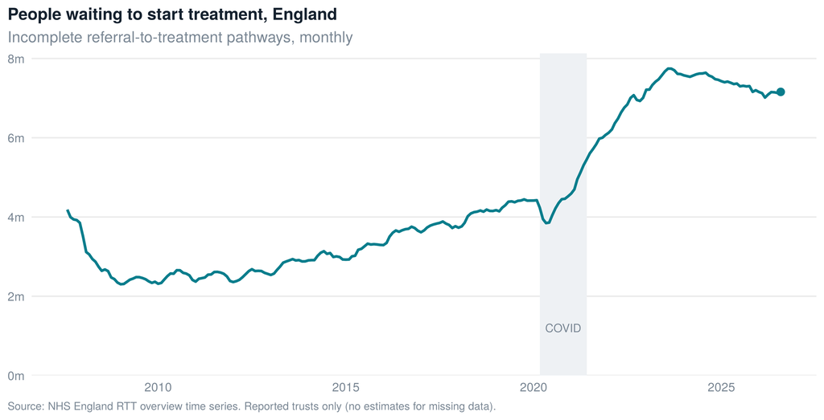

```r
ggplot(ts, aes(month, waiting / 1e6)) +
  annotate("rect", xmin = as.Date("2020-03-01"), xmax = as.Date("2021-06-01"), ymin = -Inf, ymax = Inf, fill = "#eef1f4") +
  annotate("text", x = as.Date("2020-10-15"), y = 1.2, label = "COVID", colour = muted, size = 3.2) +
  geom_line(colour = accent, linewidth = 1) +
  geom_point(data = ts |> filter(month == max(month)), colour = accent, size = 2.5) +
  scale_y_continuous(limits = c(0, NA), labels = \(x) paste0(x, "m"), expand = expansion(mult = c(0, .05))) +
  labs(title = "People waiting to start treatment, England", subtitle = "Incomplete referral-to-treatment pathways, monthly",
       x = NULL, y = NULL, caption = "Source: NHS England RTT overview time series. Reported trusts only (no estimates for missing data).")
```

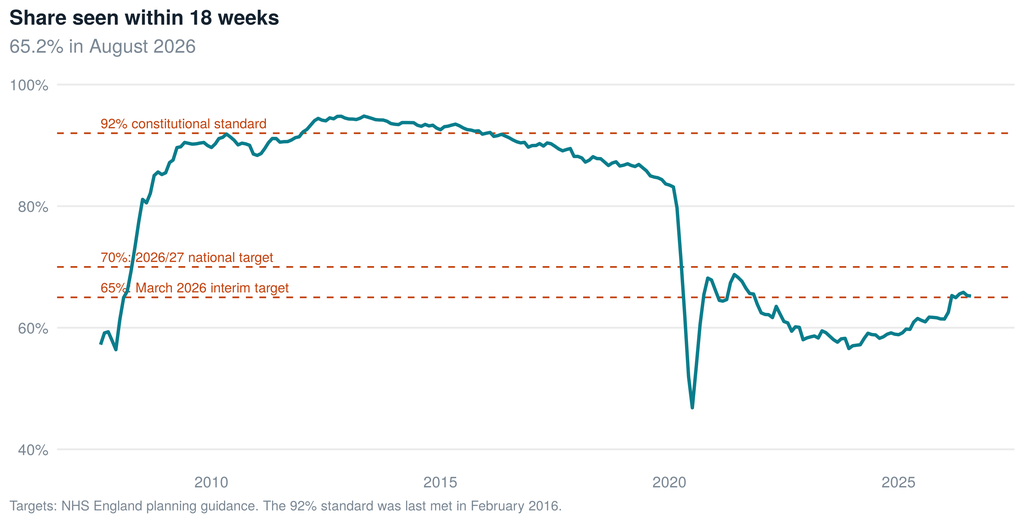

```r
targets <- tibble(y = c(92, 70, 65), lab = c("92% constitutional standard", "70%: 2026/27 national target", "65%: March 2026 interim target"))
ggplot(ts, aes(month, pct_within_18)) +
  geom_hline(data = targets, aes(yintercept = y), colour = warn, linetype = "dashed", linewidth = .5) +
  geom_text(data = targets, aes(x = min(ts$month), y = y, label = lab), colour = warn, size = 3, hjust = 0, vjust = -0.5) +
  geom_line(colour = accent, linewidth = 1) +
  scale_y_continuous(limits = c(40, 100), labels = \(x) paste0(x, "%")) +
  labs(title = "Share seen within 18 weeks", subtitle = sprintf("%s%% in %s", s$pct_within_18, s$month), x = NULL, y = NULL,
       caption = "Targets: NHS England planning guidance. The 92% standard was last met in February 2016.")
```

The list peaked at **7.75 million** in August 2023. Before COVID (February 2020) it was 4.42 million. The interim target of 65% by March 2026 was met; the 2026/27 target of 70% is still 4.8 points away.

## 2. It depends what’s wrong with you

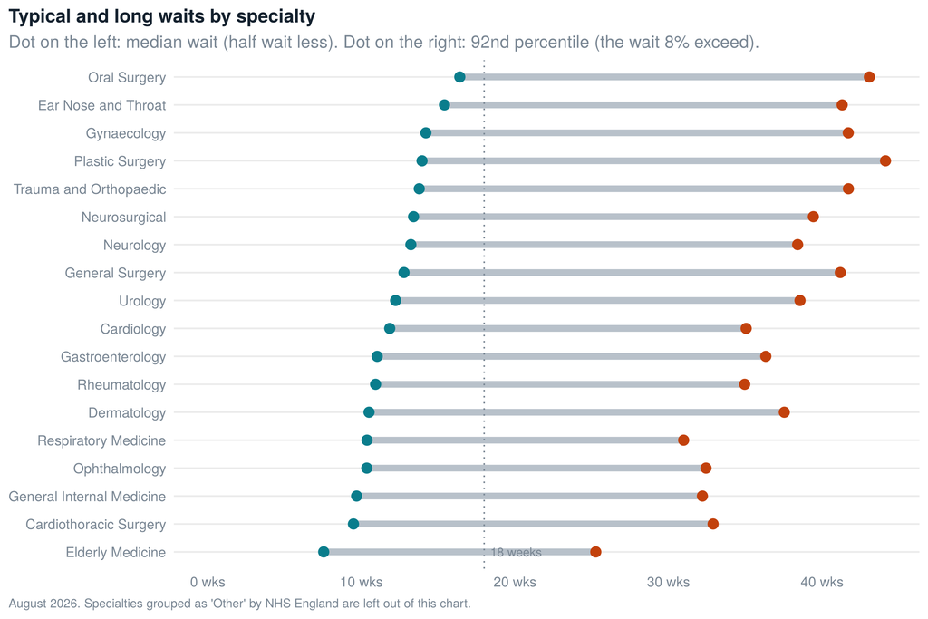

```r
sp <- spec |> filter(!str_starts(specialty, "Other")) |>
  mutate(specialty = str_remove(specialty, " Service$"), specialty = reorder(specialty, median_weeks))
ggplot(sp, aes(y = specialty)) +
  geom_segment(aes(x = median_weeks, xend = p92_weeks, yend = specialty), colour = ctx, linewidth = 2.2, lineend = "round") +
  geom_point(aes(x = median_weeks), colour = accent, size = 3) +
  geom_point(aes(x = p92_weeks), colour = warn, size = 3) +
  geom_vline(xintercept = 18, colour = muted, linetype = "dotted") +
  annotate("text", x = 18.4, y = 1, label = "18 weeks", hjust = 0, colour = muted, size = 3) +
  scale_x_continuous(limits = c(0, NA), labels = \(x) paste(x, "wks")) +
  labs(title = "Typical and long waits by specialty", x = NULL, y = NULL,
       subtitle = "Dot on the left: median wait (half wait less). Dot on the right: 92nd percentile (the wait 8% exceed).",
       caption = sprintf("%s. Specialties grouped as 'Other' by NHS England are left out of this chart.", s$month))
```

```r
spec |> filter(!str_starts(specialty, "Other")) |> arrange(pct_within_18) |>
  transmute(Specialty = str_remove(specialty, " Service$"), Waiting = fmt(waiting), `Within 18 wks` = sprintf("%.1f%%", pct_within_18),
            Median = sprintf("%.1f", median_weeks), `92nd pct` = sprintf("%.1f", p92_weeks), `Over 52 wks` = fmt(over_52)) |>
  knitr::kable(align = "lrrrrr")
```

| Specialty | Waiting | Within 18 wks | Median | 92nd pct | Over 52 wks |
| --- | --- | --- | --- | --- | --- |
| Oral Surgery | 315,652 | 53.8% | 16.4 | 43.1 | 7,537 |
| Ear Nose and Throat | 589,316 | 56.8% | 15.4 | 41.3 | 12,001 |
| Plastic Surgery | 108,674 | 59.5% | 14.0 | 44.1 | 3,521 |
| Gynaecology | 585,378 | 59.6% | 14.2 | 41.7 | 12,849 |
| Trauma and Orthopaedic | 843,419 | 61.1% | 13.8 | 41.7 | 19,741 |
| Neurosurgical | 53,980 | 62.0% | 13.4 | 39.4 | 788 |
| Neurology | 205,335 | 62.4% | 13.2 | 38.4 | 1,950 |
| General Surgery | 384,427 | 63.2% | 12.8 | 41.2 | 8,199 |
| Urology | 366,130 | 64.9% | 12.2 | 38.6 | 5,198 |
| Cardiology | 360,799 | 67.9% | 11.9 | 35.1 | 2,768 |
| Dermatology | 422,625 | 69.0% | 10.5 | 37.5 | 5,254 |
| Gastroenterology | 357,430 | 69.7% | 11.0 | 36.3 | 3,621 |
| Rheumatology | 118,118 | 70.4% | 10.9 | 35.0 | 1,065 |
| Ophthalmology | 622,784 | 72.2% | 10.4 | 32.4 | 4,975 |
| Cardiothoracic Surgery | 8,551 | 73.9% | 9.5 | 32.9 | 103 |
| Respiratory Medicine | 182,132 | 74.2% | 10.4 | 31.0 | 535 |
| General Internal Medicine | 28,907 | 74.2% | 9.7 | 32.2 | 173 |
| Elderly Medicine | 27,386 | 84.3% | 7.6 | 25.3 | 90 |

## 3. Which trusts are really different?

A league table ranks trusts even when the differences are noise. A **funnel plot** asks a better question: given how many people a trust has waiting, is its performance further from the national rate than chance allows?

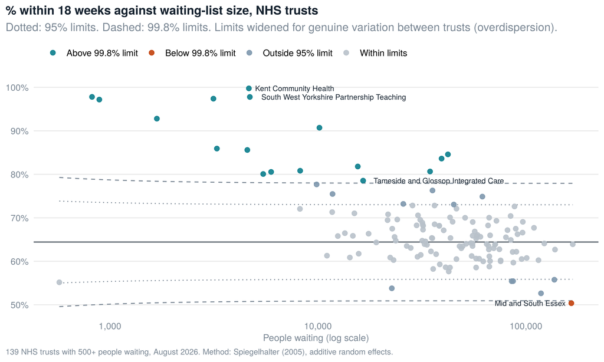

```r
fo <- funnel_overdispersed(fun$within_18, fun$waiting)
grid <- tibble(n = exp(seq(log(min(fun$waiting)), log(max(fun$waiting)), length.out = 200))) |>
  mutate(lo95 = fo$limits(n, -1.96), hi95 = fo$limits(n, 1.96), lo998 = fo$limits(n, -3.09), hi998 = fo$limits(n, 3.09))
lab <- fun |> filter(band != "Within limits", abs(z) > 3.09) |> arrange(z) |> slice(c(1:2, n() - 1, n()))
ggplot(fun, aes(waiting, 100 * p)) +
  geom_line(data = grid, aes(n, 100 * hi998), colour = muted, linetype = "dashed") +
  geom_line(data = grid, aes(n, 100 * lo998), colour = muted, linetype = "dashed") +
  geom_line(data = grid, aes(n, 100 * hi95), colour = muted, linetype = "dotted") +
  geom_line(data = grid, aes(n, 100 * lo95), colour = muted, linetype = "dotted") +
  geom_hline(yintercept = 100 * fo$p0, colour = ink, linewidth = .4) +
  geom_point(aes(colour = band), size = 2.2, alpha = .9) +
  geom_text(data = lab, aes(label = nice(str_remove(provider, " NHS.*$")), hjust = ifelse(waiting > 50000, 1.08, -0.08)), size = 2.8, colour = ink) +
  scale_colour_manual(values = c("Above 99.8% limit" = accent, "Below 99.8% limit" = warn, "Outside 95% limit" = "#7d97ad", "Within limits" = ctx), name = NULL) +
  scale_x_log10(labels = label_comma()) + scale_y_continuous(labels = \(x) paste0(x, "%")) +
  labs(title = "% within 18 weeks against waiting-list size, NHS trusts",
       subtitle = "Dotted: 95% limits. Dashed: 99.8% limits. Limits widened for genuine variation between trusts (overdispersion).",
       x = "People waiting (log scale)", y = NULL,
       caption = sprintf("%d NHS trusts with 500+ people waiting, %s. Method: Spiegelhalter (2005), additive random effects.", s$trusts, s$month))
```

On plain binomial limits, **125 of 139** trusts look like outliers, because with lists this large any difference is “significant”. Allowing for the normal spread between trusts (an extra 4.4 percentage points of variation), **17 trusts are genuinely better** than the national rate and **1 genuinely worse**. Most of the better-than-chance trusts are community, cancer or specialist trusts with simpler or more planned workloads, so the useful comparison is the large acute trusts in the middle of the funnel. Those outside the limits are the ones worth a closer look, in either direction. 75 of 139 trusts are at 65% or above; 36 are at the 70% target for 2026/27.

```r
fun |> filter(abs(z) > 3.09) |> arrange(desc(z)) |>
  transmute(Trust = nice(provider), Waiting = fmt(waiting), `Within 18 wks` = sprintf("%.1f%%", 100 * p),
            `z (adjusted)` = sprintf("%+.1f", z), Verdict = ifelse(z > 0, "Better than chance", "Worse than chance")) |>
  knitr::kable(align = "lrrrl")
```

| Trust | Waiting | Within 18 wks | z (adjusted) | Verdict |
| --- | --- | --- | --- | --- |
| Kent Community Health NHS Foundation Trust | 4,655 | 99.8% | +8.0 | Better than chance |
| South West Yorkshire Partnership Teaching NHS Foundation Trust | 4,705 | 97.8% | +7.5 | Better than chance |
| The Christie NHS Foundation Trust | 3,144 | 97.4% | +7.4 | Better than chance |
| Cornwall Partnership NHS Foundation Trust | 820 | 97.8% | +7.1 | Better than chance |
| The Clatterbridge Cancer Centre NHS Foundation Trust | 889 | 97.2% | +7.0 | Better than chance |
| The Royal Marsden NHS Foundation Trust | 1,681 | 92.8% | +6.3 | Better than chance |
| Midlands Partnership University NHS Foundation Trust | 10,166 | 90.7% | +6.0 | Better than chance |
| Lancashire & South Cumbria NHS Foundation Trust | 3,267 | 85.9% | +4.8 | Better than chance |
| Hampshire and Isle of Wight Healthcare NHS Foundation Trust | 4,576 | 85.6% | +4.8 | Better than chance |
| Moorfields Eye Hospital NHS Foundation Trust | 42,168 | 84.6% | +4.6 | Better than chance |
| Northumbria Healthcare NHS Foundation Trust | 39,301 | 83.6% | +4.4 | Better than chance |
| Birmingham Community Healthcare NHS Foundation Trust | 15,544 | 81.8% | +4.0 | Better than chance |
| Shropshire Community Health NHS Trust | 8,213 | 80.8% | +3.7 | Better than chance |
| Royal Berkshire NHS Foundation Trust | 34,597 | 80.7% | +3.7 | Better than chance |
| Royal Papworth Hospital NHS Foundation Trust | 5,955 | 80.6% | +3.7 | Better than chance |
| Liverpool Heart and Chest Hospital NHS Foundation Trust | 5,455 | 80.1% | +3.5 | Better than chance |
| Tameside and Glossop Integrated Care NHS Foundation Trust | 16,489 | 78.5% | +3.2 | Better than chance |
| Mid and South Essex NHS Foundation Trust | 165,277 | 50.4% | -3.2 | Worse than chance |

## 4. NHS and independent providers

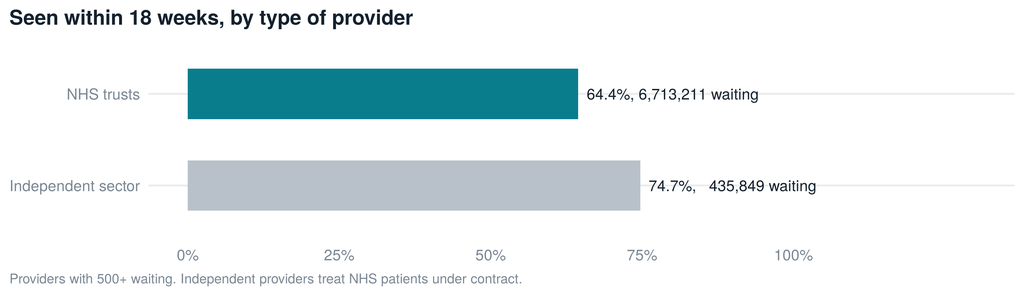

```r
sec <- prov |> filter(!small) |> group_by(sector = ifelse(independent, "Independent sector", "NHS trusts")) |>
  summarise(waiting = sum(waiting), within_18 = sum(within_18)) |> mutate(pct = 100 * within_18 / waiting)
ggplot(sec, aes(pct, sector)) + geom_col(fill = c(ctx, accent)[as.integer(sec$sector == "NHS trusts") + 1], width = .55) +
  geom_text(aes(label = sprintf("%.1f%%, %s waiting", pct, fmt(waiting))), hjust = -0.05, size = 3.4, colour = ink) +
  scale_x_continuous(limits = c(0, 130), breaks = seq(0, 100, 25), labels = \(x) paste0(x, "%")) +
  labs(title = "Seen within 18 weeks, by type of provider", x = NULL, y = NULL,
       caption = "Providers with 500+ waiting. Independent providers treat NHS patients under contract.")
```

Independent providers see 74.7% within 18 weeks against 64.4% for NHS trusts, but they hold only 6.1% of the list and mostly take routine, lower-complexity cases. This is not a like-for-like comparison.

## 5. Raw to clean

The two raw files are kept exactly as downloaded in `data/raw`. `scripts/01_clean.R` turns them into tidy tables and logs every check:

```r
dq |> select(Source = source, Check = check, Rows = rows_affected, Finding = finding, Action = action) |>
  mutate(Rows = fmt(Rows)) |> knitr::kable()
```

| Source | Check | Rows | Finding | Action |
| --- | --- | --- | --- | --- |
| timeseries | Months read | 228 | Aug 2007 to Aug 2026 | One row per month; title block, two-row header and footnotes dropped |
| timeseries | Not collected (‘-’) | 164 | Waits over 65, 78 and 104 weeks were not collected in early years | Kept as missing, not zero |
| timeseries | 92nd percentile off the scale (‘52+’) | 9 | Early months record the 92nd percentile as text ‘52+’ | Set to missing with a flag column |
| timeseries | Mislabelled column | 228 | ‘Total waiting (mil)’ holds counts of pathways, not millions | Read as a count |
| extract | Rows read | 177,770 | 177,770 rows, 121 columns, period RTT-August-2026 | - |
| extract | Incomplete pathways | 63,444 | Part 2 rows: people still waiting (other parts are completed pathways and new referrals) | Kept |
| extract | Weekly bands | 105 | 0-1 weeks to 103-104 weeks, then 104+ | Summed per group; percentiles interpolated within bands |
| extract | Empty ‘Total’ column | 63,444 | Part 2 leaves ‘Total’ blank; ‘Total All’ holds the row total | Totals recomputed from the bands |
| extract | Specialty ‘Total’ rows | 12,895 | Each provider-commissioner pair has a ‘Total’ row (C_999) as well as its specialty rows | Totals used for England and trust figures; specialty rows for specialty figures, so nothing is counted twice |
| extract | Non-English commissioners (NONC) | 31,049 | Patients treated in England but commissioned elsewhere (e.g. Wales) | Excluded from England figures (commissioner basis, as published); kept in trust figures (provider basis) |
| reconciliation | England, August 2026 | 1 | Extract: 7,158,164 waiting, median 12.21, 92nd 38.80, 109,936 over 52 weeks. Published: 7,158,164, 12.21, 38.80, 109,936 | Matches |
| extract | Small providers | 179 | Providers with fewer than 500 people waiting (mostly independent sector clinics) | Kept in the data; left out of the funnel plot, where tiny lists dominate the scale |
| output | Clean tables | 4 | england_timeseries, specialty_summary, provider_summary, provider_specialty | Written to data/clean |